# Faye Harwell- Zombie Apocolapse Homework

Faye Harwell

September 28, 2017

# ZOMBIE Homework… we got some killin’ to do!

### To get started, load your badass dataset:

```r
library(curl)
f <- f <- curl("https://raw.githubusercontent.com/fuzzyatelin/fuzzyatelin.github.io/master/AN597_Fall17/zombies.csv")
d <- read.csv(f, header = TRUE, sep = ",", stringsAsFactors = FALSE)
head(d)
```

```
##   id first_name last_name gender   height   weight zombies_killed
## 1  1      Sarah    Little Female 62.88951 132.0872              2
## 2  2       Mark    Duncan   Male 67.80277 146.3753              5
## 3  3    Brandon     Perez   Male 72.12908 152.9370              1
## 4  4      Roger   Coleman   Male 66.78484 129.7418              5
## 5  5      Tammy    Powell Female 64.71832 132.4265              4
## 6  6    Anthony     Green   Male 71.24326 152.5246              1
##   years_of_education                           major      age
## 1                  1                medicine/nursing 17.64275
## 2                  3 criminal justice administration 22.58951
## 3                  1                       education 21.91276
## 4                  6                  energy studies 18.19058
## 5                  3                       logistics 21.10399
## 6                  4                  energy studies 21.48355
```

```r
d
```

[output not shown]

[output cut: 1987 more lines]

### Question 1: Calculate dem means… what doooo you mean?

```r
mean(d$height)->avg_height
avg_height
```

```
## [1] 67.6301
```

```r
mean(d$weight)->avg_weight
avg_weight
```

```
## [1] 143.9075
```

```r
mean(d$zombies_killed)->avg_zombieskilled
avg_zombieskilled
```

```
## [1] 2.992
```

```r
mean(d$years_of_education)->avg_years_of_education
avg_years_of_education
```

```
## [1] 2.996
```

```r
population_size <-length(d$id)
population_size
```

```
## [1] 1000
```

### The fun part is computing variance by hand… everyone enjoys that..

```r
var_height<-(sum((d$height-avg_height)^2)/(1000))
var_height
```

```
## [1] 18.55861
```

```r
var_weight<-(sum((d$weight-avg_weight)^2)/(1000))
var_weight
```

```
## [1] 338.2604
```

```r
var_zombieskilled<-(sum((d$zombies_killed-avg_zombieskilled)^2)/(1000))
var_zombieskilled
```

```
## [1] 3.053936
```

```r
var_years_of_education<-(sum((d$years_of_education-avg_years_of_education)^2)/(1000))
var_years_of_education
```

```
## [1] 2.807984
```

### Let’s pull it all together… actually we are going to squareroot the sh*t out of this stuff

```r
sd_height <- sqrt(var_height)
sd_height
```

```
## [1] 4.30797
```

```r
sd_weight <- sqrt(var_weight)
sd_weight
```

```
## [1] 18.39186
```

```r
sd_zombieskilled <- sqrt(var_zombieskilled)
sd_zombieskilled
```

```
## [1] 1.747551
```

```r
sd_years_of_education <- sqrt(var_years_of_education)
sd_years_of_education
```

```
## [1] 1.675704
```

## Question 2: G-G Plotting… any thing to do with G-G rubbing.. Hopefully, not…

### Boxing a plot of males and females for Height

```r
library(ggplot2)
```

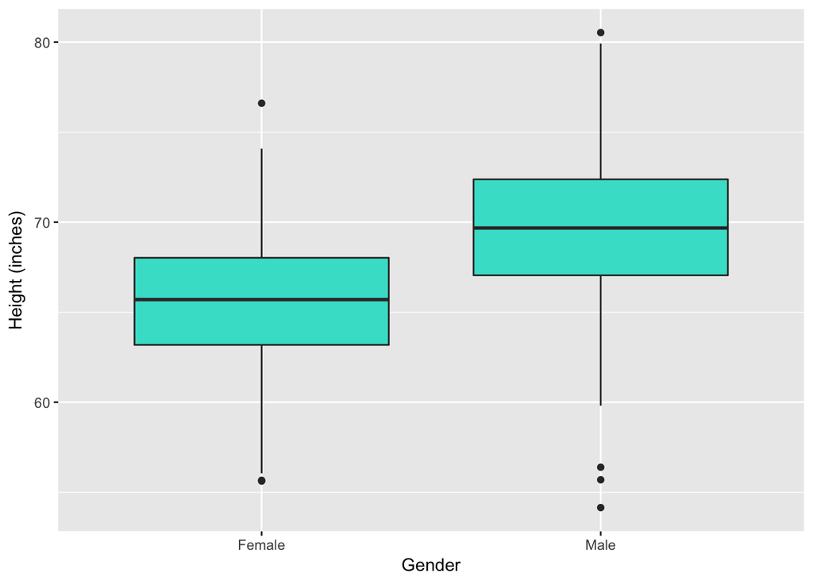

```r
ggplot(aes(y = height, x = gender), data = d) + ylab("Height (inches)") + xlab("Gender") +geom_boxplot(fill= "turquoise")->boxplot_height
boxplot_height
```

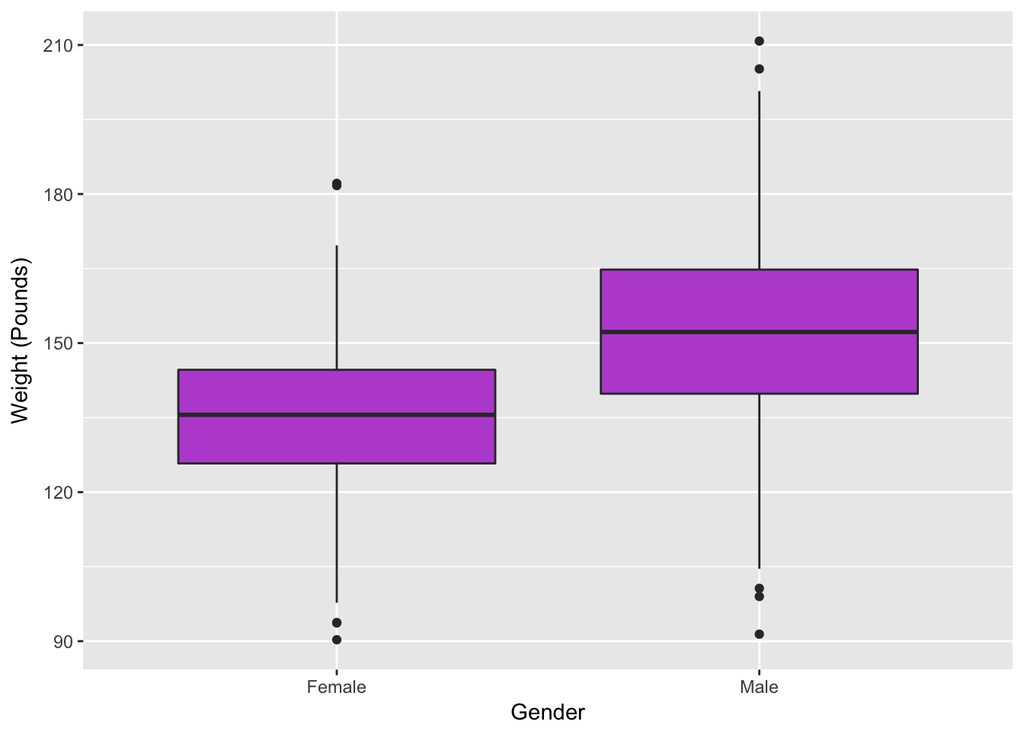

```r
ggplot(aes(y = weight, x = gender), data = d) +ylab("Weight (Pounds)") + xlab("Gender") + geom_boxplot(fill= "mediumorchid")->boxplot_weight
boxplot_weight
```

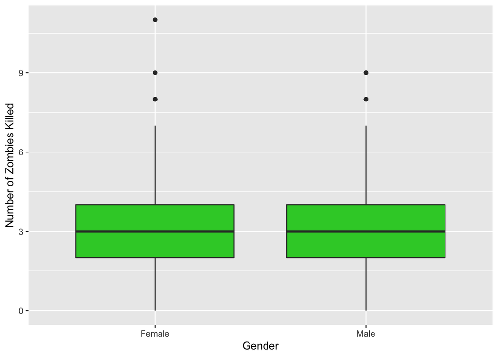

```r
ggplot(aes(y = zombies_killed, x = gender), data = d) + ylab("Number of Zombies Killed") + xlab("Gender") + geom_boxplot(fill= "limegreen")->boxplot_zombieskilled
boxplot_zombieskilled
```

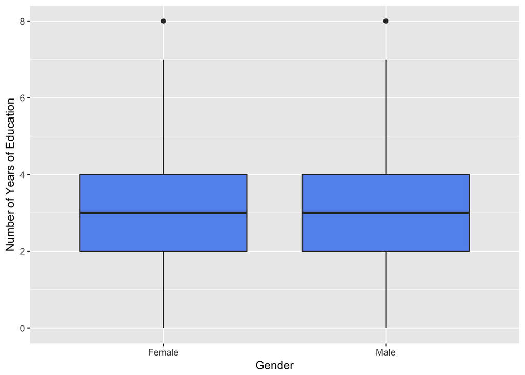

```r
ggplot(aes(y = years_of_education, x = gender), data = d) + ylab("Number of Years of Education") + xlab("Gender") + geom_boxplot(fill= "cornflowerblue")->boxplot_education
boxplot_education
```

## Question 3: More G-G rubbing… I mean plotting. This time around do some scattering of the plot (aka a scatterplot!)

#### Both scatterplots show a positive relationship/correlation (although I have not gone ahead and tested whether it is significant). This means that as you get older, you are likely to be heavier and taller… I like when data is straight forward and makes sense!

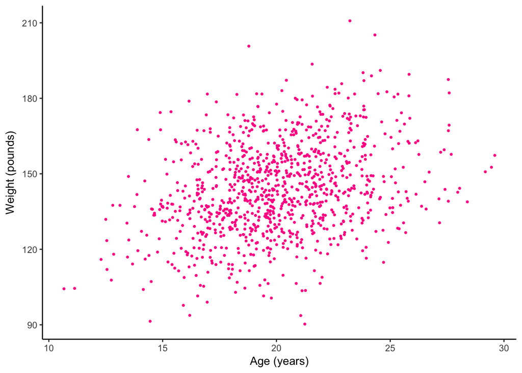

```r
ggplot(d, aes(age, weight)) + xlab("Age (years)") + ylab("Weight (pounds)")+
  geom_point(shape = 16, size = 1, show.legend = FALSE, colour = ("deeppink1")) + theme_classic()
```

[figure not shown]

```r
ggplot(d, aes(age, height)) + xlab("Age (years)") + ylab("Height (inches)")+
  geom_point(shape = 16, size = 1, show.legend = FALSE, colour = ("mediumspringgreen")) + theme_classic()
```

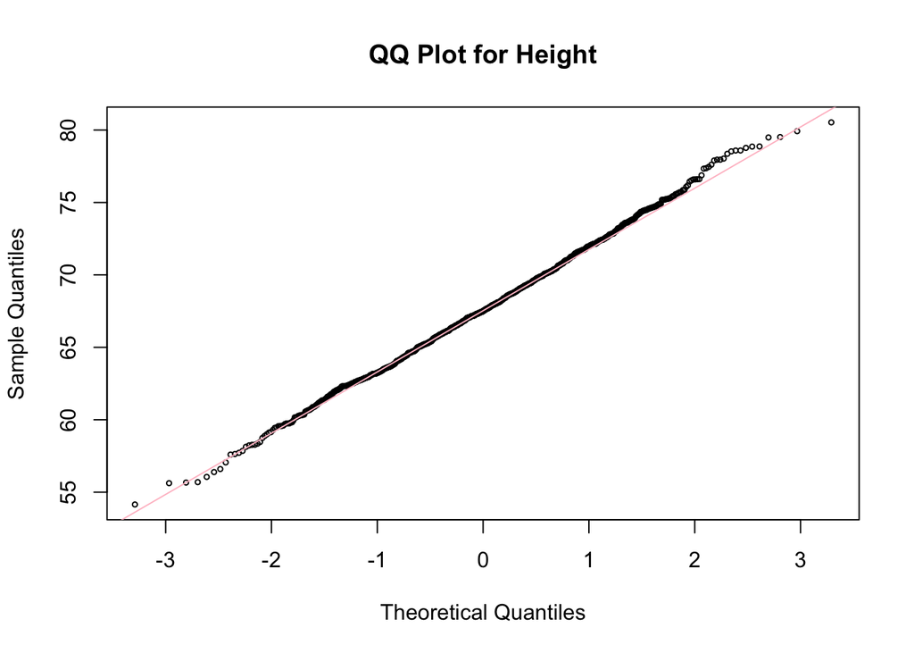

```r
qqnorm(d$height, cex=0.5, main="QQ Plot for Height")
qqline(d$height, col="pink")
```

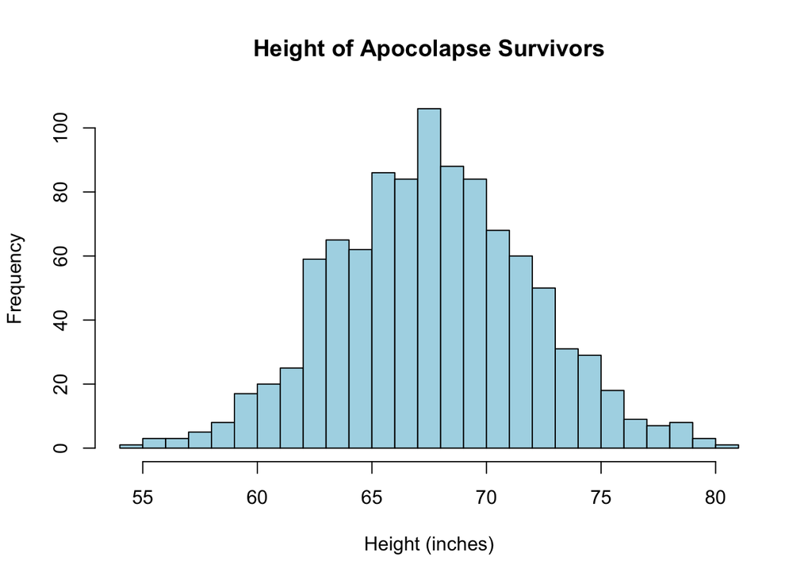

```r
hist(d$height, main="Height of Apocolapse Survivors", breaks=20, xlab="Height (inches)", ylab="Frequency", col="lightblue")
```

### In my expert opinion, height is looking pretty darn normal. In the Q-Q plot, you see a very nice straight line plotted for sample quantiles plotted against theoretical quantiles. Likewise, the histogram of the frequency of heights is bell-shaped.

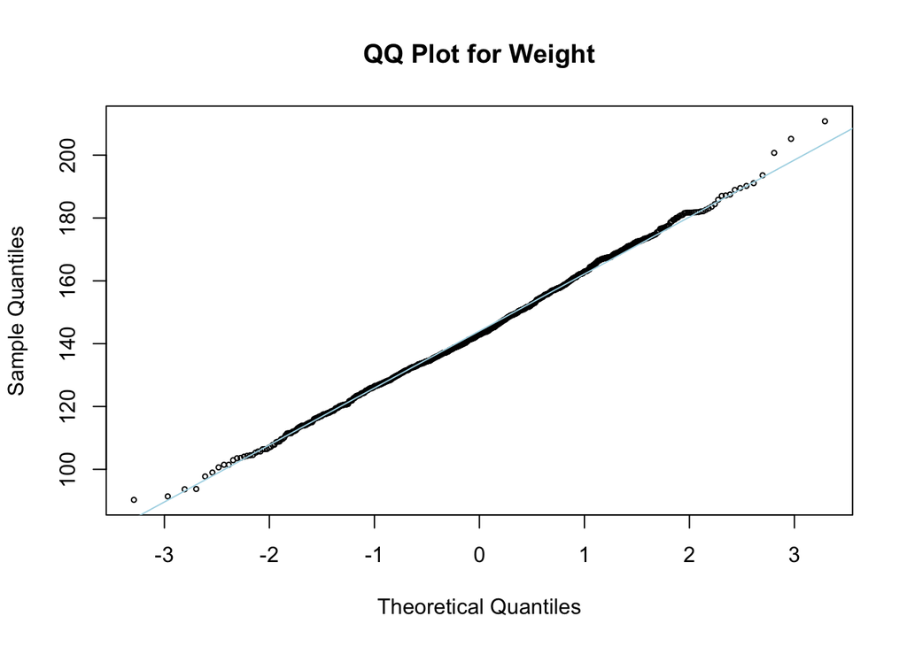

```r
qqnorm(d$weight, cex=0.5, main="QQ Plot for Weight")
qqline(d$weight, col="lightblue")
```

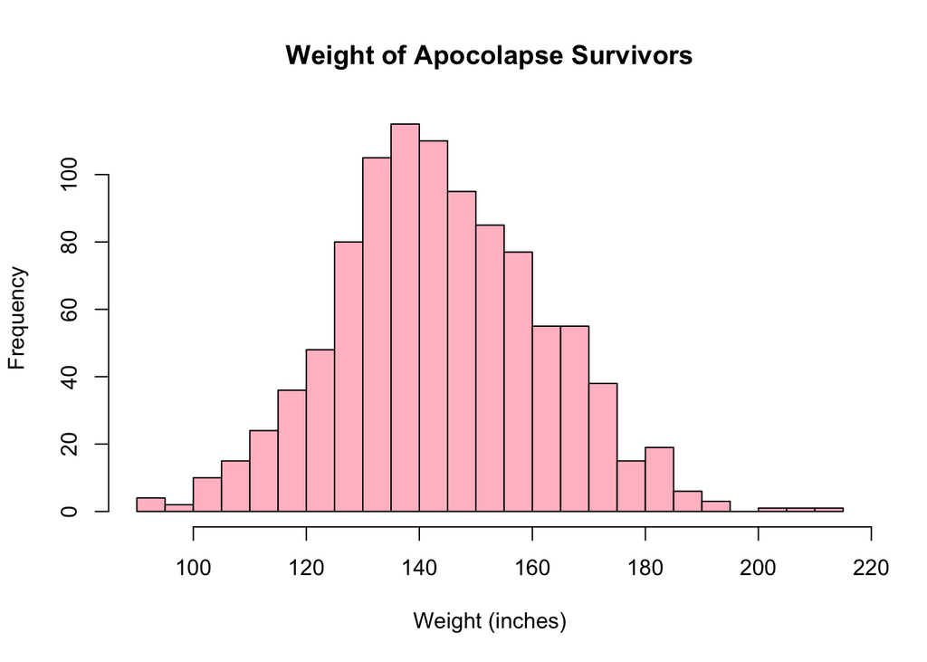

```r
hist(d$weight, main="Weight of Apocolapse Survivors", breaks=20, xlab="Weight (inches)", ylab="Frequency", col="pink")
```

### Again, very normal looking. Both in the histogram and the Q-Q plot you see the points being normally distributed (i.e. straight line for sample quantiles plotted against theoretical quantiles and nice bell-shaped curve)

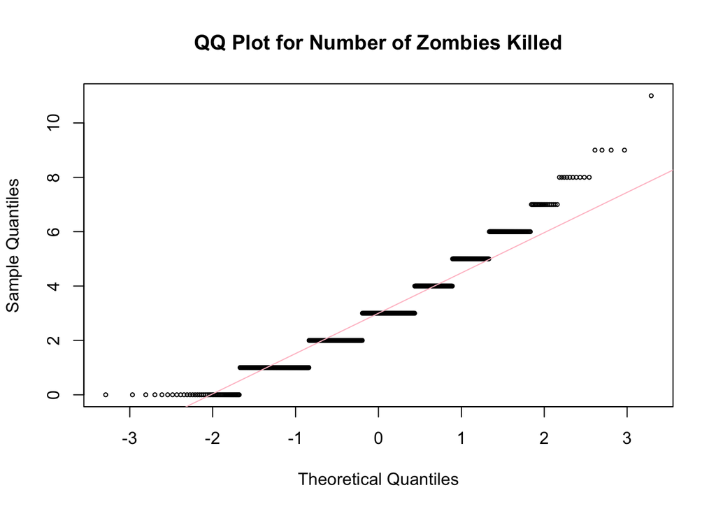

```r
qqnorm(d$zombies_killed, cex=0.5, main="QQ Plot for Number of Zombies Killed")
qqline(d$zombies_killed, col="pink")
```

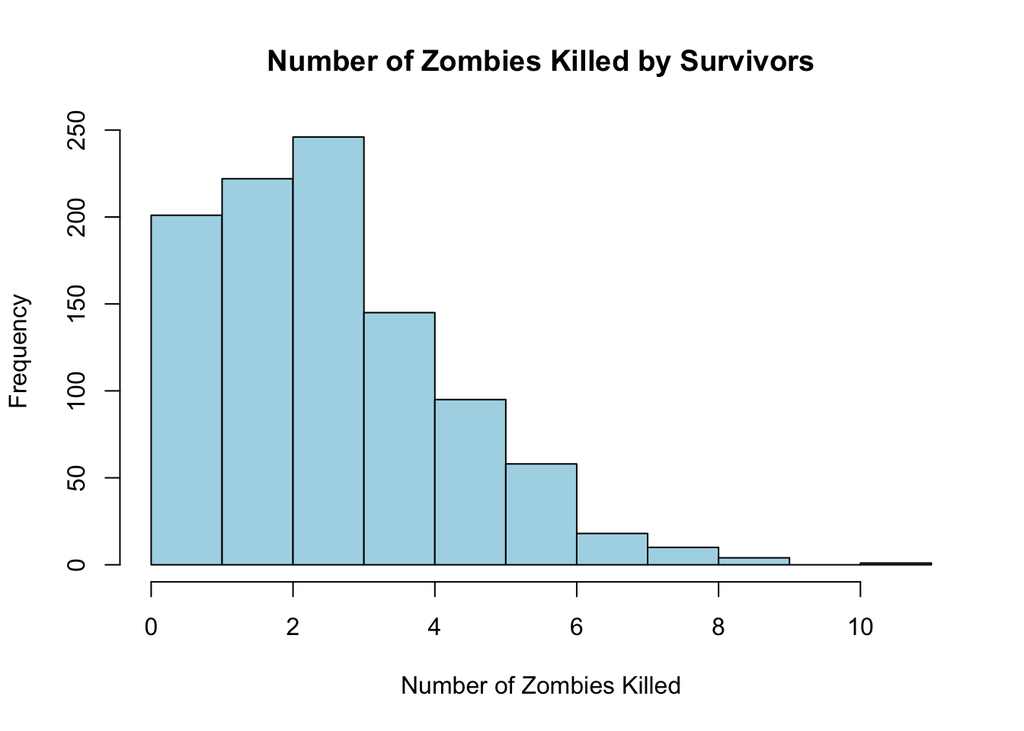

```r
hist(d$zombies_killed, main="Number of Zombies Killed by Survivors",breaks=10, xlab="Number of Zombies Killed", ylab="Frequency", col="lightblue")
```

### Both the Q-Q plot and the histogram showing the number of zombies killed by survivors do not follow a normal distribution. The histogram shows a right skew distribution. I predict that this may be a poisson distribution as it is highly skewed.

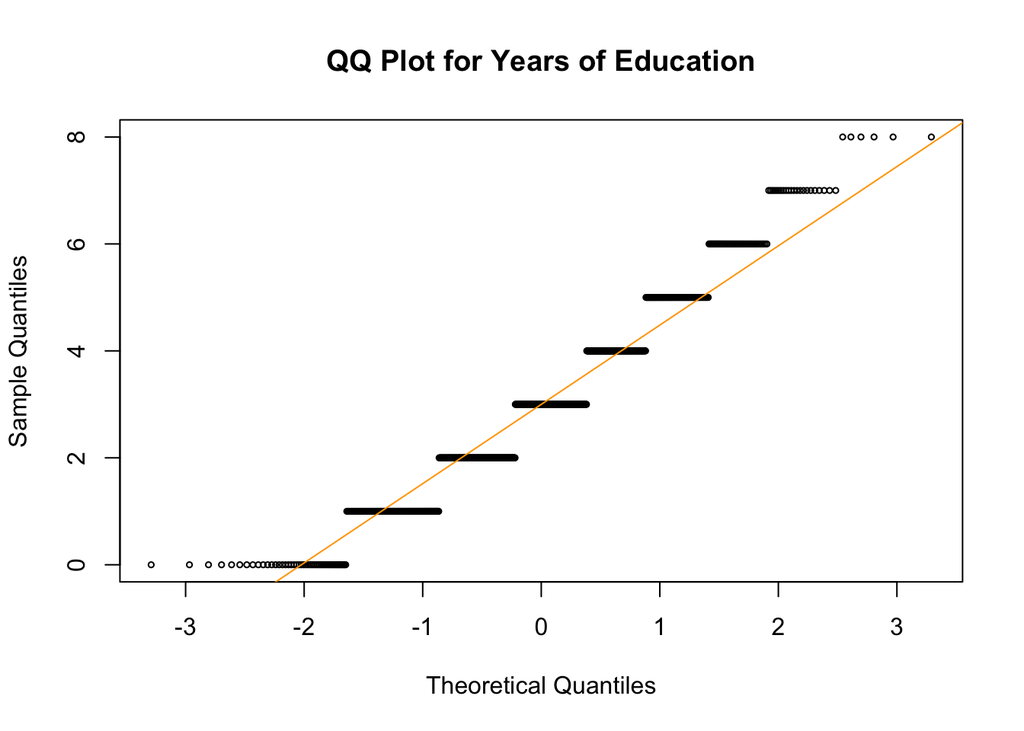

```r
qqnorm(d$years_of_education, cex=0.5, main="QQ Plot for Years of Education")
qqline(d$years_of_education, col="orange")
```

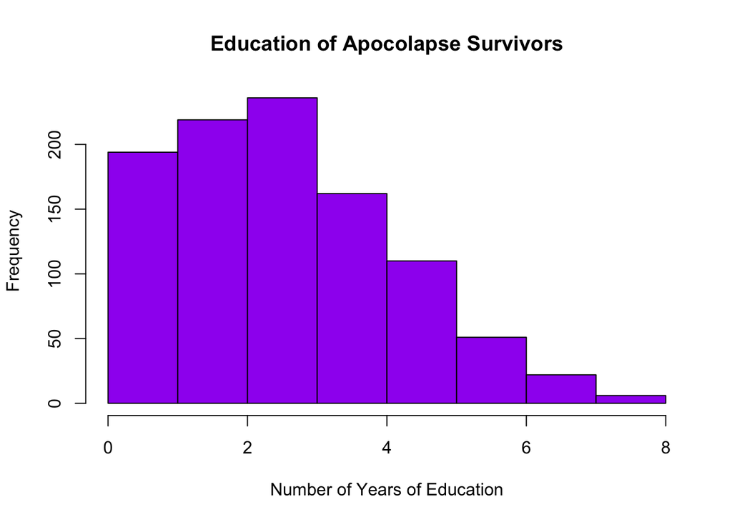

```r
hist(d$years_of_education, main="Education of Apocolapse Survivors",breaks= 10, xlab="Number of Years of Education", ylab="Frequency", col="purple")
```

### Both the Q-Q plot and the histogram showing the number of years of education of survivors do not follow a normal distribution. The histogram shows a right skew distribution. I predict that this may be a poisson distribution as it is highly skewed.

## Question 5: Random Sampling!

```r
library(dplyr)
sample(d$id, size= 30, replace = FALSE, prob = NULL)-> random_rows
d %>% slice(random_rows)-> random30
```

```r
library(dplyr)
d[sample(nrow(d),30),]
```

```
##      id first_name  last_name gender   height    weight zombies_killed
## 198 198   Clarence    Gilbert   Male 69.16849 154.57143              2
## 660 660     Walter     Hanson   Male 69.24513 139.59607              5
## 545 545     Nicole    Schmidt Female 63.19721 106.39948              4
## 493 493    Marilyn     Howell Female 58.27686  90.29148              1
## 34   34   Lawrence   Richards   Male 71.14842 167.40555              2
## 605 605   Patricia    Chapman Female 69.53375 155.27477              2
## 466 466      James   Matthews   Male 64.26664 140.33744              4
## 479 479      Irene       Cook Female 64.11557 121.84962              3
## 200 200       Eric      Lopez   Male 74.67166 176.90675              1
## 943 943    Rebecca       Hall Female 64.09073 132.40476              5
## 25   25   Lawrence   Phillips   Male 74.47760 163.64636              8
## 681 681       Carl      Scott   Male 72.49018 154.35665              5
## 584 584       Carl       Reid   Male 68.37091 161.80092              4
## 323 323    Raymond      Price   Male 71.48824 153.94991              1
```

[output cut: 47 more lines]

```r
random30
```

```
## # A tibble: 30 x 10
##       id first_name last_name gender   height   weight zombies_killed
##    <int>      <chr>     <chr>  <chr>    <dbl>    <dbl>          <int>
##  1   898       Sean    Romero   Male 69.87416 169.4200              5
##  2   778      Jason      Hart   Male 67.69585 143.8266              3
##  3   970     Eugene  Ferguson   Male 60.32218 104.5811              5
##  4    44      Shawn    Harris   Male 66.90534 132.5518              1
##  5   257      Aaron    Medina   Male 68.89152 154.1242              4
##  6   178     Cheryl     Clark Female 64.18962 143.4554              2
##  7   465       Paul       Fox   Male 74.34293 174.2580              3
##  8   398  Christina      West Female 67.40818 143.7683              2
##  9   997      Julie     Evans Female 66.48566 157.0878              3
## 10   309      Tammy    Porter Female 64.87039 123.6400              2
## # ... with 20 more rows, and 3 more variables: years_of_education <int>,
## #   major <chr>, age <dbl>
```

### NOW, instead of doing these god forsaken equations again… copy from above Question 1’s work (Standard Deviation & Mean done out by hand)

```r
mean(random30$height)->avg_height30
avg_height30
```

```
## [1] 67.10463
```

```r
mean(random30$weight)->avg_weight30
avg_weight30
```

```
## [1] 145.0437
```

```r
mean(random30$zombies_killed)->avg_zombieskilled30
avg_zombieskilled30
```

```
## [1] 3.166667
```

```r
mean(random30$years_of_education)->avg_years_of_education30
avg_years_of_education30
```

```
## [1] 2.966667
```

### COPIED: The fun part is computing variance by hand… everyone enjoys that..

```r
var_height30<-(sum((random30$height-avg_height30)^2)/(30))
var_height30
```

```
## [1] 22.33383
```

```r
var_weight30<-(sum((random30$weight-avg_weight30)^2)/(30))
var_weight30
```

```
## [1] 471.7241
```

```r
var_zombieskilled30<-(sum((random30$zombies_killed-avg_zombieskilled30)^2)/(30))
var_zombieskilled30
```

```
## [1] 2.672222
```

```r
var_years_of_education30<-(sum((random30$years_of_education-avg_years_of_education30)^2)/(30))
var_years_of_education30
```

```
## [1] 2.032222
```

### COPIED: Let’s pull it all together… actually we are going to squareroot the sh*t out of this stuff

```r
sd_height30 <- sqrt(var_height30)
sd_height30
```

```
## [1] 4.725868
```

```r
sd_weight30 <- sqrt(var_weight30)
sd_weight30
```

```
## [1] 21.71921
```

```r
sd_zombieskilled30 <- sqrt(var_zombieskilled30)
sd_zombieskilled30
```

```
## [1] 1.634693
```

```r
sd_years_of_education30 <- sqrt(var_years_of_education30)
sd_years_of_education30
```

```
## [1] 1.42556
```

### Even better, you get to do standard error calculations… aren’t you a lucky ducky

```r
se_height30<-sd_height30/sqrt(30)
se_height30
```

```
## [1] 0.8628215
```

```r
se_weight30<-sd_weight30/sqrt(30)
se_weight30
```

```
## [1] 3.965367
```

```r
se_zombieskilled30<-sd_zombieskilled30/sqrt(30)
se_zombieskilled30
```

```
## [1] 0.2984528
```

```r
se_years_of_education30<-sd_years_of_education30/sqrt(30)
se_years_of_education30
```

```
## [1] 0.2602705
```

### Lucky Ducky, I got more news for you- you get to do confidence intervals.

```r
c(avg_height30-2*se_height30, avg_height30+2*se_height30)
```

```
## [1] 65.37899 68.83028
```

```r
c(avg_weight30-2*se_weight30, avg_weight30+2*se_weight30)
```

```
## [1] 137.1130 152.9744
```

### You are guessing that zombies killed follows a Poisson Distribution. Therefore, you calculated confidence intervals slightly differently than you previously had done for the normally distributed variables (Height and Weight)

```r
c(avg_zombieskilled30+1.96*(avg_zombieskilled30/30), avg_zombieskilled30-1.96*(avg_zombieskilled30/30))
```

```
## [1] 3.373556 2.959778
```

```r
c(avg_years_of_education30+1.96*(avg_years_of_education30/30), avg_years_of_education30-1.96*(avg_years_of_education30/30))
```

```
## [1] 3.160489 2.772844
```

## Question 5: Random sampling… again… 99 more times to be precise…

### Hmmm maybe replicate () will be helpful… or not.

```r
replicated_99 <- replicate(99,d[sample(nrow(d),30),])
replicated_99
```

[output not shown]

[output cut: 220 more lines]

[output not shown]

### Faye, remember that you have terrible naming abilities and you named your ‘height’ variables hah and haha

```r
hah=0
replicated_99[5,]-> heights99
for (i in 1:99){
  hah[i] <- mean(heights99[[i]])
}
hah
```

```
##  [1] 68.01361 67.92472 67.58162 69.13234 66.78551 66.83352 68.36367
##  [8] 67.79731 67.47361 67.56451 67.38990 68.84459 66.84570 67.56074
## [15] 67.71741 67.08231 67.53440 68.16970 66.44599 68.40032 67.41297
## [22] 68.02068 67.27581 68.18013 66.94890 67.07984 67.18999 66.96762
## [29] 68.72278 65.24491 67.22514 67.43835 66.85110 68.43064 66.87892
## [36] 67.94445 66.18932 67.46877 68.01929 67.60200 65.82794 68.02897
## [43] 68.24222 69.21696 68.12071 68.01412 66.71545 68.15972 67.02249
## [50] 67.37555 67.45252 68.70164 67.96679 68.23101 65.76936 64.78566
## [57] 67.90902 67.27886 67.43854 67.59530 67.14833 66.94691 68.71739
## [64] 67.59042 68.79593 66.92310 68.57209 67.99180 68.26156 66.65135
## [71] 67.37468 68.88681 67.54318 66.88517 67.87065 66.16011 67.50050
## [78] 67.98725 66.31596 67.31556 66.46514 65.89518 67.83786 67.22439
## [85] 67.88328 68.35562 68.44429 67.19457 68.12504 67.72339 67.39201
## [92] 67.94956 67.98191 67.60610 67.74814 68.47419 67.60762 67.06245
## [99] 67.54157
```

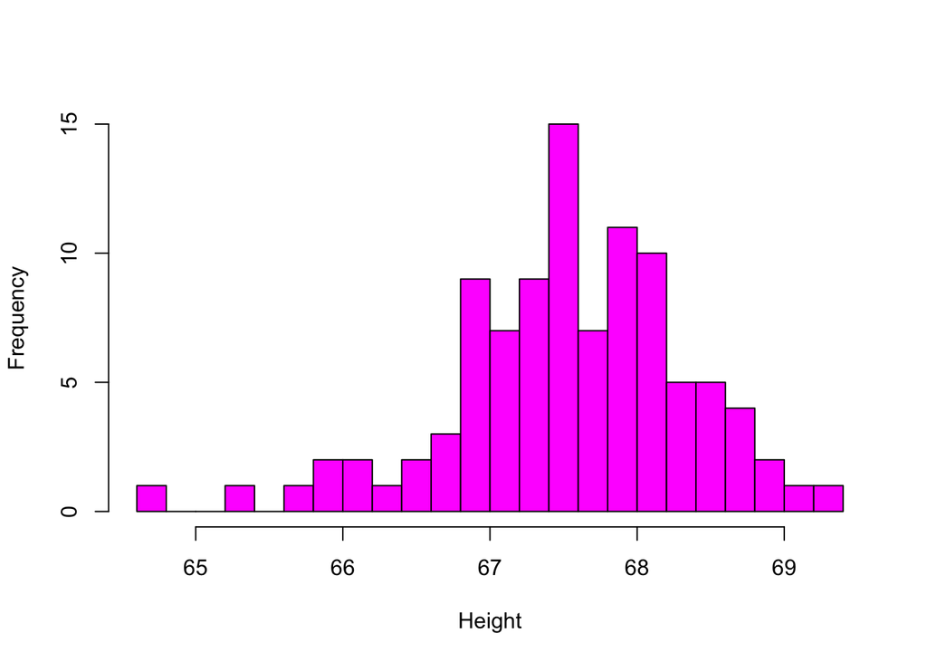

```r
#Histogram to look at the distribution
hist(hah, col="magenta", breaks=20, xlab= "Height", main= NULL)
```

```r
# This is a mean of means- you will need this to calculate variance
mean(hah)-> haha
haha
```

```
## [1] 67.53896
```

```r
#Going back and continuing to calculate variance and standard deviation
var_haha<-(sum((hah-haha)^2)/(99))
var_haha
```

```
## [1] 0.640959
```

```r
sd_haha <-sqrt(var_haha)
sd_haha
```

```
## [1] 0.8005991
```

### Do better names this time round (good thing you do this like 4 more times)

### This is for Weight (lala, lalala)

```r
lala=0
replicated_99[6,]-> weights99
for (i in 1:99){
  lala[i] <- mean(weights99[[i]])
}
lala
```

```
##  [1] 144.2492 142.4781 145.5164 149.8948 143.9911 142.1590 145.2854
##  [8] 144.0047 143.3695 144.4700 146.0682 145.4965 143.2820 143.1108
## [15] 146.0406 143.4778 144.1385 147.1785 138.2399 145.6579 143.2756
## [22] 146.4743 141.3608 142.6174 144.6000 143.3966 143.6181 142.9411
## [29] 146.9749 135.4467 143.6042 142.9476 140.7916 145.2836 142.7367
## [36] 144.4359 137.6140 144.1235 144.0660 142.7288 137.3623 146.5788
## [43] 147.3935 151.0829 147.2453 143.3771 141.5623 146.4292 140.0474
## [50] 146.3019 142.9414 145.9885 145.8952 144.6304 136.4803 131.3080
## [57] 143.4321 144.9314 143.1293 144.2115 143.7773 143.3028 145.7574
## [64] 143.3049 146.6573 143.3963 145.7323 145.0710 145.8836 140.8252
## [71] 140.6120 148.1481 147.1579 141.8720 143.7091 139.4797 140.2608
## [78] 144.1155 141.2713 139.9384 143.1459 138.2246 144.9312 142.4782
## [85] 141.9870 145.3323 147.0525 141.4451 143.4224 146.0494 145.9830
## [92] 146.3762 144.4331 146.4281 142.9589 146.0206 143.4090 143.6492
## [99] 141.2045
```

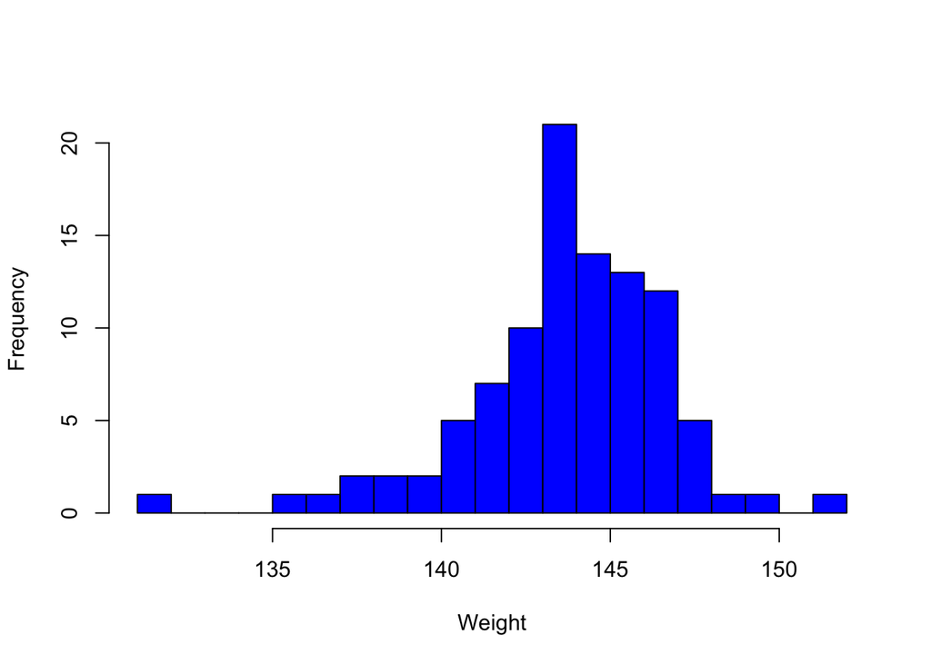

```r
#Histogram to look at the distribution
hist(lala, col="blue", breaks=20, xlab= "Weight", main= NULL)
```

```r
# This is a mean of means- you will need this to calculate variance
mean(lala)-> lalala
lalala
```

```
## [1] 143.6594
```

```r
#Going back and continuing to calculate variance and standard deviation
var_lala<-(sum((lala-lalala)^2)/(99))
var_lala
```

```
## [1] 8.658042
```

```r
sd_lala <-sqrt(var_lala)
sd_lala
```

```
## [1] 2.942455
```

### This is for Number of Zombies Killed

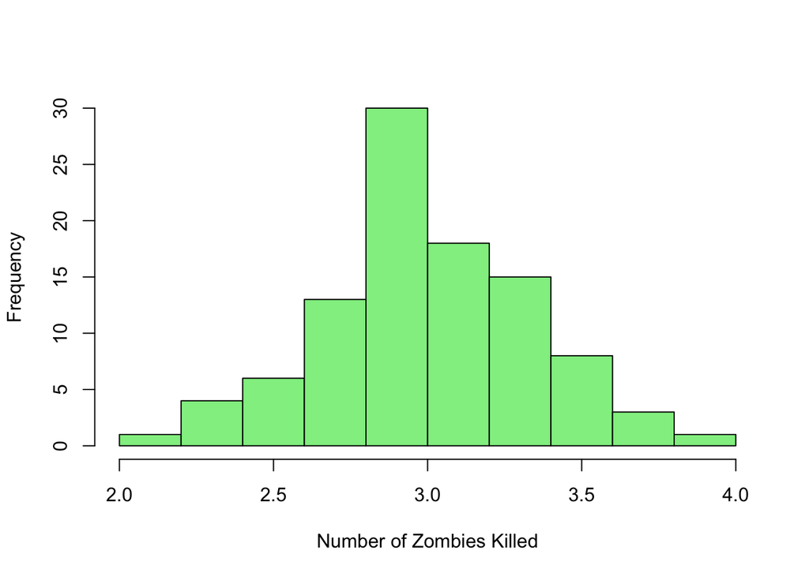

```r
hehe=0
replicated_99[7,]-> zombieskilled99
hehe <- 0
for (i in 1:99){
  hehe[i] <- mean(zombieskilled99[[i]])
}

#Histogram to look at the distribution
hist(hehe,col="lightgreen", breaks=10, main=NULL, xlab= "Number of Zombies Killed")
```

```r
# This is a mean of means- you will need this to calculate variance
hehe
```

```
##  [1] 3.533333 3.333333 2.600000 2.800000 2.533333 2.300000 3.133333
##  [8] 2.866667 3.066667 2.300000 3.233333 2.933333 2.766667 3.000000
## [15] 3.133333 2.866667 3.433333 2.966667 3.933333 2.766667 2.866667
## [22] 3.266667 3.366667 2.666667 2.966667 2.766667 2.133333 3.200000
## [29] 3.300000 3.100000 3.566667 3.200000 2.766667 2.833333 2.933333
## [36] 3.700000 2.900000 2.900000 3.233333 2.966667 3.766667 3.533333
## [43] 3.066667 2.600000 3.333333 3.700000 3.133333 2.966667 3.366667
## [50] 3.100000 2.833333 3.000000 2.800000 2.900000 3.100000 3.033333
## [57] 3.433333 3.333333 3.600000 3.000000 2.933333 2.733333 3.166667
## [64] 2.800000 3.366667 2.966667 3.266667 2.733333 3.266667 2.766667
## [71] 3.000000 3.200000 3.133333 3.000000 2.833333 3.000000 3.133333
## [78] 3.033333 2.600000 2.833333 2.866667 3.200000 3.100000 2.600000
## [85] 2.966667 2.633333 2.333333 3.533333 3.466667 2.566667 2.966667
## [92] 2.700000 3.366667 3.400000 2.366667 2.900000 3.000000 2.966667
## [99] 3.300000
```

```r
mean(hehe)-> hehehe
hehehe
```

```
## [1] 3.027609
```

```r
#Going back and continuing to calculate variance and standard deviation
var_hehe<-(sum((hehe-hehehe)^2)/(99))
var_hehe
```

```
## [1] 0.1120099
```

```r
sd_hehe <-sqrt(var_hehe)
sd_hehe
```

```
## [1] 0.3346788
```

### This is for Number of Years of Education

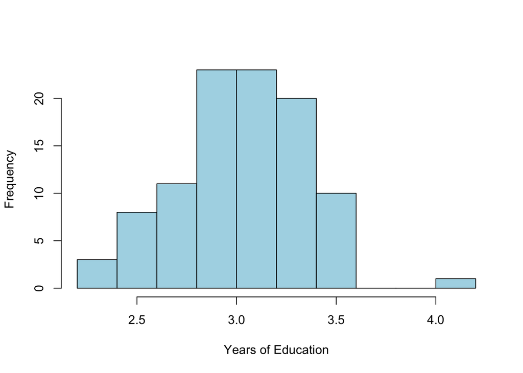

```r
dumdum=0
replicated_99[8,]-> yearsofeducation99
dumdum <- 0
for (i in 1:99){
  dumdum[i] <- mean(yearsofeducation99[[i]])
}

#Histogram to look at the distribution
hist(dumdum, col="lightblue", breaks= 10, xlab= "Years of Education", main= NULL)
```

```r
# This is a mean of means- you will need this to calculate variance
dumdum
```

```
##  [1] 3.300000 3.300000 3.466667 2.600000 3.066667 2.566667 3.366667
##  [8] 3.000000 3.233333 3.033333 3.200000 3.000000 3.133333 2.666667
## [15] 2.933333 2.566667 2.400000 3.266667 3.433333 3.100000 2.933333
## [22] 2.866667 2.900000 3.066667 3.533333 2.966667 3.233333 2.700000
## [29] 3.366667 3.033333 3.400000 3.300000 2.933333 3.233333 2.700000
## [36] 2.633333 3.466667 2.866667 3.066667 2.966667 3.400000 3.266667
## [43] 2.700000 3.133333 3.333333 3.033333 2.533333 2.966667 3.500000
## [50] 3.066667 2.900000 3.500000 2.266667 2.733333 3.100000 3.200000
## [57] 3.466667 3.333333 2.700000 2.500000 2.733333 3.000000 2.433333
## [64] 3.133333 3.166667 3.133333 2.766667 2.966667 2.966667 2.466667
## [71] 3.000000 3.300000 3.000000 3.333333 3.100000 3.200000 2.766667
## [78] 3.200000 3.266667 3.000000 3.400000 2.933333 3.200000 3.600000
## [85] 4.066667 3.133333 3.500000 3.000000 3.366667 2.933333 2.400000
## [92] 2.500000 2.666667 3.033333 3.133333 3.233333 3.433333 3.000000
## [99] 3.000000
```

```r
mean(dumdum)-> dumdumdum
dumdumdum
```

```
## [1] 3.049495
```

```r
#Going back and continuing to calculate variance and standard deviation
var_dumdum<-(sum((dumdum-dumdumdum)^2)/(99))
var_dumdum
```

```
## [1] 0.09980614
```

```r
sd_dumdum <-sqrt(var_dumdum)
sd_dumdum
```

```
## [1] 0.3159211
```